# Group A — Yogurt Study: Final Presentation

Author

Workshop Participant

## 1. What biological question did you investigate?

> **Does eating yogurt help *Lactobacillus crispatus* — the protective vaginal bacterium — recover after antibiotic treatment?**

> Antibiotics disrupt the vaginal microbiome by killing bacteria indiscriminately. We wanted to know if eating yogurt (which contains bacteria) helps *L. crispatus* bounce back faster compared to an unchanged diet.

## 2. Who are the participants?

```r
participants |>
  select(-pid, -sex) |>
  tbl_summary(
    by = arm,
    statistic = list(age ~ "{mean} ({sd})")
  ) |>
  add_p() |>
  add_overall() |>
  bold_labels() |>
  modify_header(label = "**Characteristic**")
```

| **Characteristic** | **Overall** N = 51<sup>1</sup> | **unchanged_diet** N = 25<sup>1</sup> | **yogurt** N = 26<sup>1</sup> | **p-value**<sup>2</sup> |
| --- | --- | --- | --- | --- |
| days_since_last_sex | 5 (3, 11) | 6 (3, 10) | 5 (3, 11) | 0.8 |
| birth_control |  |  |  | 0.017 |
| Depoprovera | 25 (49%) | 8 (32%) | 17 (65%) |  |
| no hormonal birth control | 26 (51%) | 17 (68%) | 9 (35%) |  |
| age | 30.7 (3.3) | 30.4 (3.3) | 31.0 (3.3) | 0.6 |
| education |  |  |  | 0.8 |
| grade 10-12, matriculated | 10 (20%) | 6 (24%) | 4 (15%) |  |
| grade 10-12, not matriculated | 21 (41%) | 9 (36%) | 12 (46%) |  |
| less than grade 9 | 9 (18%) | 4 (16%) | 5 (19%) |  |
| post-secondary | 11 (22%) | 6 (24%) | 5 (19%) |  |

<sup>1</sup> Median (Q1, Q3); n (%); Mean (SD)  
<sup>2</sup> Wilcoxon rank sum test; Pearson’s Chi-squared test; Fisher’s exact test

**Key takeaways:**

- **51 participants** (25 unchanged diet, 26 yogurt) — roughly balanced
- **Age similar** across groups (mean ≈ 31 in both, p = 0.55)
- But **birth control is imbalanced**: 17 of 26 yogurt participants use Depoprovera vs. only 8 of 25 in the unchanged diet group. This could matter for the microbiome.

## 3. What did you compare, and what did you find?

### Main finding: *L. crispatus* recovery after antibiotics

In the **yogurt group**, 85% of samples had detectable *L. crispatus* after antibiotics. In the **unchanged diet group**, only 48% did.

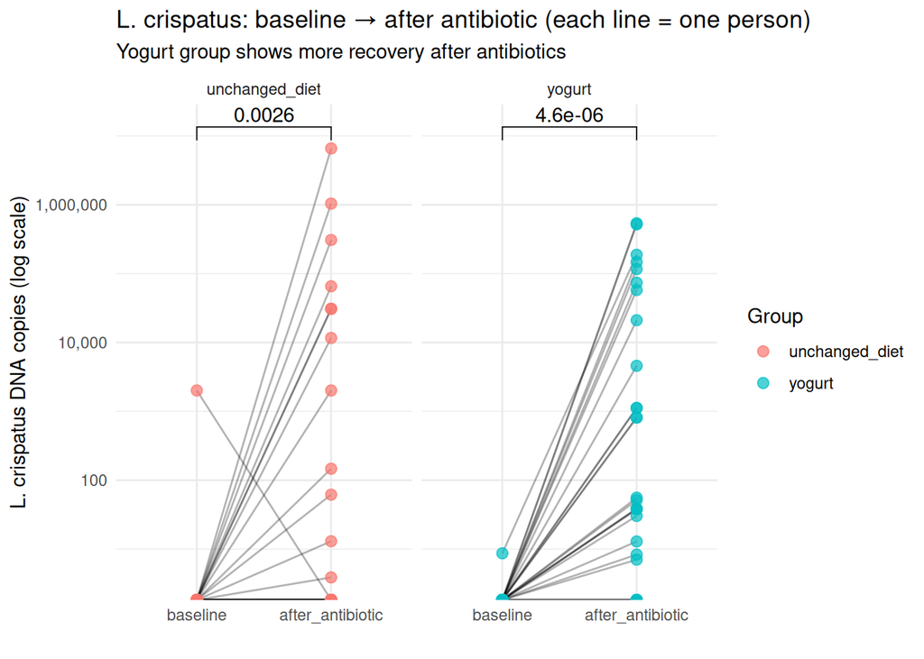

```r
# Prepare paired data for L. crispatus
qpcr_joined |>
  filter(time_point %in% c("baseline", "after_antibiotic")) |>
  mutate(time_point = fct_relevel(time_point, "baseline", "after_antibiotic")) |>
  ggplot(aes(time_point, qpcr_crispatus)) +
  geom_line(aes(group = pid), alpha = 0.3) +
  geom_point(aes(color = arm), size = 2.5, alpha = 0.7) +
  facet_wrap(~ arm) +
  scale_y_log10(labels = scales::comma) +
  labs(
    title = "L. crispatus: baseline → after antibiotic (each line = one person)",
    subtitle = "Yogurt group shows more recovery after antibiotics",
    y = "L. crispatus DNA copies (log scale)",
    x = "",
    color = "Group"
  ) +
  stat_compare_means(
    method = "wilcox.test",
    paired = TRUE,
    comparisons = list(c("baseline", "after_antibiotic"))
  ) +
  theme_minimal()
```